# IODS course project

#### The explanatory variables and their relationships with alcohol consumption

Let us start with the variable “age”.

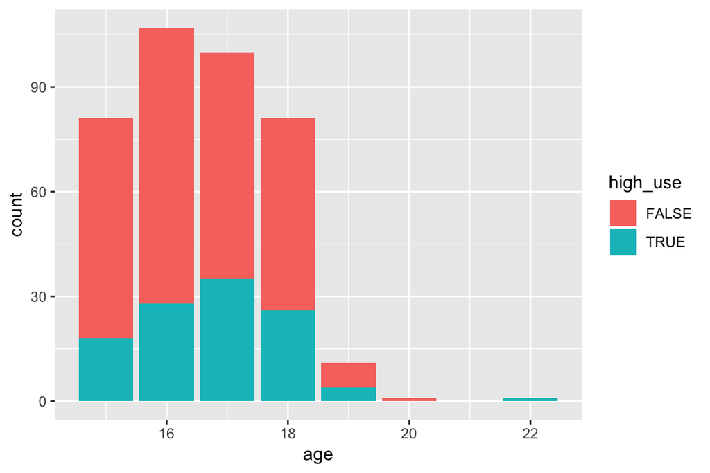

```r
library(ggplot2)
ggplot(data = alc, aes(x = age, fill = high_use)) + geom_bar()
```

What we see is that we have a pick at the age of 17.

The second variable is school.

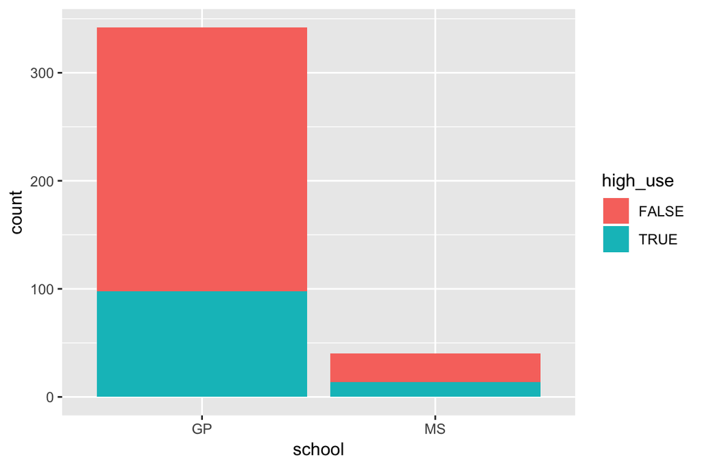

```r
ggplot(data = alc, aes(x = school, fill = high_use)) + geom_bar()
```

It’s quite hard to say if alcohol consumption is bigger in one of the schools. In our further analysis, it might turn out that this variable and our response variable are independent.

The next graph is about alcohol consumption and family.

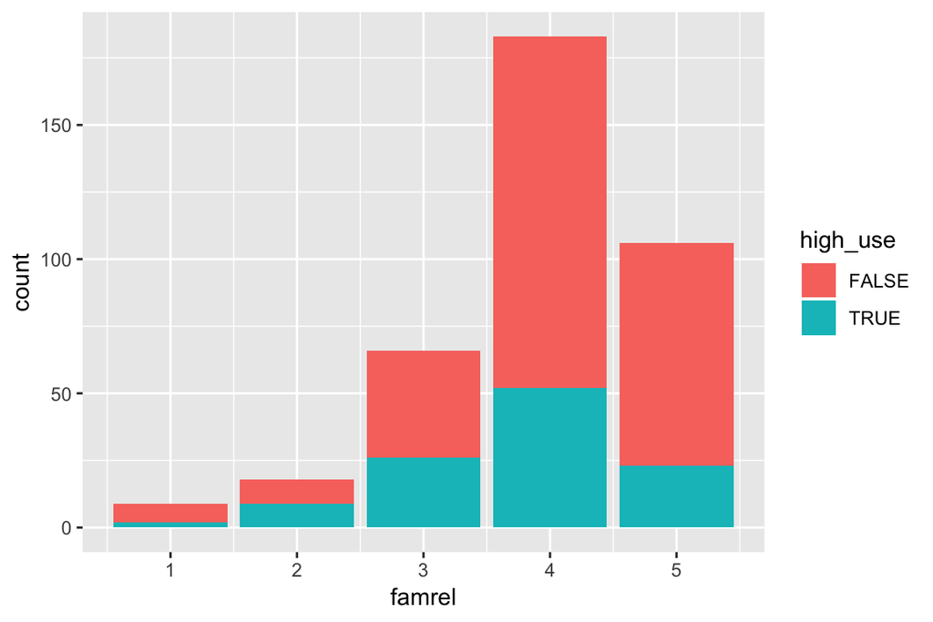

```r
ggplot(data = alc, aes(x = famrel, fill = high_use)) + geom_bar()
```

```r
library(dplyr)
t <- table(family = alc$famrel, high_use = alc$high_use)
t
```

```
##       high_use
## family FALSE TRUE
##      1     7    2
##      2     9    9
##      3    40   26
##      4   131   52
##      5    83   23
```

```r
for (i in 1:nrow(t)) {
  sum <- t[i,1] + t[i,2]
  t[i, 1] <- t[i,1]/sum
  t[i, 2] <- t[i,2]/sum
}
t
```

```
##       high_use
## family     FALSE      TRUE
##      1 0.7777778 0.2222222
##      2 0.5000000 0.5000000
##      3 0.6060606 0.3939394
##      4 0.7158470 0.2841530
##      5 0.7830189 0.2169811
```

Based on this last table, we can say that there is a negative correlation between this variable and the response variable.

Also, let us see if students who want to continue their studies are not heavy drinkers.

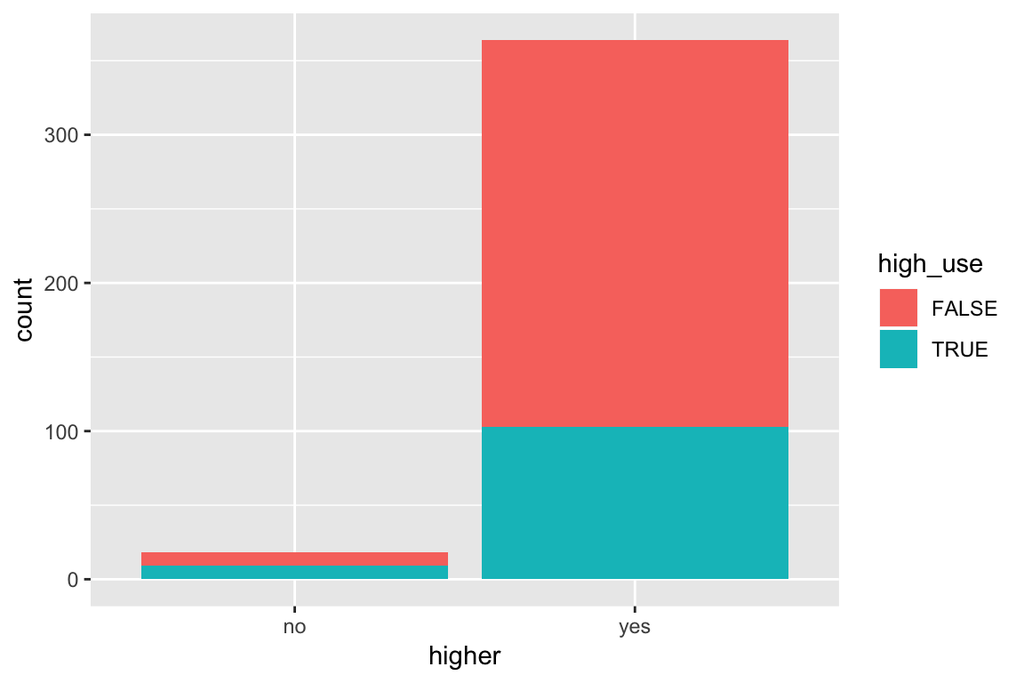

```r
ggplot(data = alc, aes(x = higher, fill = high_use)) + geom_bar()
```

```r
t <- table(family = alc$higher, high_use = alc$high_use)
t
```

```
##       high_use
## family FALSE TRUE
##    no      9    9
##    yes   261  103
```

```r
for (i in 1:nrow(t)) {
  sum <- t[i,1] + t[i,2]
  t[i, 1] <- t[i,1]/sum
  t[i, 2] <- t[i,2]/sum
}
t
```

```
##       high_use
## family    FALSE     TRUE
##    no  0.500000 0.500000
##    yes 0.717033 0.282967
```

It seems that my hypothesis is quite true.

#### The logistic regression

Not it is time to use logistic regression to statistically explore the relationship between the variables and the binary high/low alcohol consumption variable as the target variable.

```r
model <- glm(high_use ~ age + school + famrel + higher, data = alc, family = "binomial")
summary(model)
```

```
##
## Call:
## glm(formula = high_use ~ age + school + famrel + higher, family = "binomial",
##     data = alc)
##
## Deviance Residuals:
##     Min       1Q   Median       3Q      Max
## -1.3740  -0.8320  -0.7316   1.3546   1.8605
##
## Coefficients:
##             Estimate Std. Error z value Pr(>|z|)
## (Intercept) -2.01814    1.96224  -1.028   0.3037
## age          0.17710    0.10748   1.648   0.0994 .
## schoolMS    -0.01764    0.38515  -0.046   0.9635
## famrel      -0.29855    0.12189  -2.449   0.0143 *
## higheryes   -0.68147    0.50601  -1.347   0.1781
## ---
## Signif. codes:  0 '***' 0.001 '**' 0.01 '*' 0.05 '.' 0.1 ' ' 1
##
## (Dispersion parameter for binomial family taken to be 1)
##
##     Null deviance: 462.21  on 381  degrees of freedom
## Residual deviance: 449.89  on 377  degrees of freedom
## AIC: 459.89
##
## Number of Fisher Scoring iterations: 4
```

Based on the result we got from fitting the model, the only variable “famrel” is statistically significant.

The odd ratios of the coefficients and their 95% confindence intervals are below:

```r
exp(cbind(coef(model), confint(model)))
```

```
##                             2.5 %    97.5 %
## (Intercept) 0.1329027 0.002799011 6.2614310
## age         1.1937562 0.967246744 1.4759900
## schoolMS    0.9825138 0.452417639 2.0657936
## famrel      0.7418952 0.583097300 0.9419763
## higheryes   0.5058743 0.185373265 1.3859659
```

Here we have one more evidence of the fact that only “famrel” is statistically significant. Its confidence interval does not contain 1 and so it does have an effect on alcohol consumption. Others’ confidence interval contains 1, so there is no evidence that they really affect our response variable.

#### The predictive power of the model

Now we are going to create a model that contains only “farmel” as an explanatory variable.

```r
model <- glm(high_use ~ famrel, data = alc, family = "binomial")
summary(model)
```

```
##
## Call:
## glm(formula = high_use ~ famrel, family = "binomial", data = alc)
##
## Deviance Residuals:
##     Min       1Q   Median       3Q      Max
## -1.1631  -0.8220  -0.7244   1.4489   1.7125
##
## Coefficients:
##             Estimate Std. Error z value Pr(>|z|)
## (Intercept)   0.2587     0.4744   0.545   0.5855
## famrel       -0.2925     0.1197  -2.445   0.0145 *
## ---
## Signif. codes:  0 '***' 0.001 '**' 0.01 '*' 0.05 '.' 0.1 ' ' 1
##
## (Dispersion parameter for binomial family taken to be 1)
##
##     Null deviance: 462.21  on 381  degrees of freedom
## Residual deviance: 456.24  on 380  degrees of freedom
## AIC: 460.24
##
## Number of Fisher Scoring iterations: 4
```

So, let us explore the predictive power of this model.

```r
probabilities <- predict(model, type = "response")
alc <- mutate(alc, probability = probabilities)
alc <- mutate(alc, prediction = probabilities > 0.5)
loss_func <- function(class, prob) {
  n_wrong <- abs(class - prob) > 0.5
  mean(n_wrong)
}
loss_func(class = alc$high_use, prob = alc$probability)
```

```
## [1] 0.2931937
```

```r
table(high_use = alc$high_use, prediction = alc$prediction) %>% prop.table() %>% addmargins()
```

```
##         prediction
## high_use     FALSE       Sum
##    FALSE 0.7068063 0.7068063
##    TRUE  0.2931937 0.2931937
##    Sum   1.0000000 1.0000000
```

```r
library(boot)
cv <- cv.glm(data = alc, cost = loss_func, glmfit = model, K = 10)
cv$delta[1]
```

```
## [1] 0.3036649
```

The average number of wrong predictions is 0.29, which is bigger than the one in datacamp exercise.

# Exercise 4

## Data downloading and exploring

```r
library(MASS)
data(Boston)
str(Boston)
```

```
## 'data.frame':    506 obs. of  14 variables:
##  $ crim   : num  0.00632 0.02731 0.02729 0.03237 0.06905 ...
##  $ zn     : num  18 0 0 0 0 0 12.5 12.5 12.5 12.5 ...
##  $ indus  : num  2.31 7.07 7.07 2.18 2.18 2.18 7.87 7.87 7.87 7.87 ...
##  $ chas   : int  0 0 0 0 0 0 0 0 0 0 ...
##  $ nox    : num  0.538 0.469 0.469 0.458 0.458 0.458 0.524 0.524 0.524 0.524 ...
##  $ rm     : num  6.58 6.42 7.18 7 7.15 ...
##  $ age    : num  65.2 78.9 61.1 45.8 54.2 58.7 66.6 96.1 100 85.9 ...
##  $ dis    : num  4.09 4.97 4.97 6.06 6.06 ...
##  $ rad    : int  1 2 2 3 3 3 5 5 5 5 ...
##  $ tax    : num  296 242 242 222 222 222 311 311 311 311 ...
##  $ ptratio: num  15.3 17.8 17.8 18.7 18.7 18.7 15.2 15.2 15.2 15.2 ...
##  $ black  : num  397 397 393 395 397 ...
##  $ lstat  : num  4.98 9.14 4.03 2.94 5.33 ...
##  $ medv   : num  24 21.6 34.7 33.4 36.2 28.7 22.9 27.1 16.5 18.9 ...
```

This dataset contains information collected by the U.S Census Service concerning housing in the area of Boston Mass. The dataset is small in size with only 506 cases. There are 14 attributes in each case of the dataset. They are:

- CRIM - per capita crime rate by town
- ZN - proportion of residential land zoned for lots over 25,000 sq.ft.
- INDUS - it serves as a proxy for the externalities with industry (noise, heavy traffic)
- CHAS - Charles River dummy variable (1 if tract bounds river; 0 otherwise)
- NOX - nitric oxides concentration (parts per 10 million)
- RM - average number of rooms per dwelling
- AGE - is related to structure quality
- DIS - weighted distances to five Boston employment centres
- RAD - index of accessibility to radial highways
- TAX - full-value property-tax rate per $10,000
- PTRATIO - pupil-teacher ratio by town
- B - 1000(Bk - 0.63)^2 where Bk is the proportion of blacks by town
- LSTAT - % lower status of the population
- MEDV - Median value of owner-occupied homes in $1000’s

All varaibles are numerical. No every variable is continious.

## Overview of the data

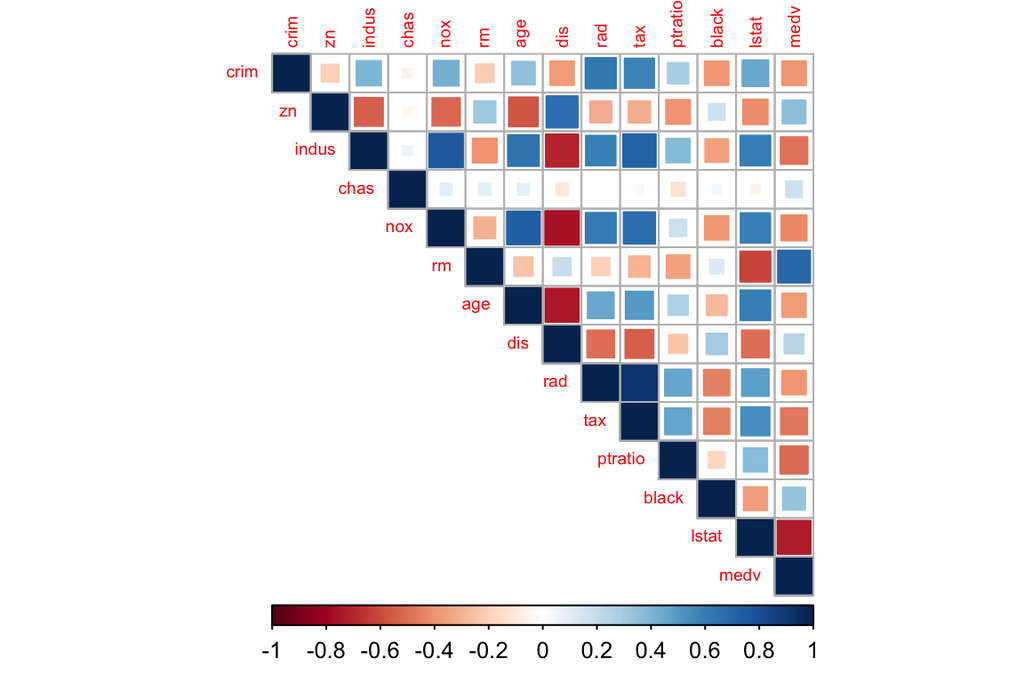

```r
library(tidyverse)
library(corrplot)
corr_matrix <- cor(Boston)
corrplot(corr_matrix, method = 'square', type = 'upper', cl.pos = 'b', tl.cex = 0.6)
```

```r
summary(Boston)
```

```
##       crim                zn             indus            chas
##  Min.   : 0.00632   Min.   :  0.00   Min.   : 0.46   Min.   :0.00000
##  1st Qu.: 0.08204   1st Qu.:  0.00   1st Qu.: 5.19   1st Qu.:0.00000
##  Median : 0.25651   Median :  0.00   Median : 9.69   Median :0.00000
##  Mean   : 3.61352   Mean   : 11.36   Mean   :11.14   Mean   :0.06917
##  3rd Qu.: 3.67708   3rd Qu.: 12.50   3rd Qu.:18.10   3rd Qu.:0.00000
##  Max.   :88.97620   Max.   :100.00   Max.   :27.74   Max.   :1.00000
##       nox               rm             age              dis
##  Min.   :0.3850   Min.   :3.561   Min.   :  2.90   Min.   : 1.130
##  1st Qu.:0.4490   1st Qu.:5.886   1st Qu.: 45.02   1st Qu.: 2.100
##  Median :0.5380   Median :6.208   Median : 77.50   Median : 3.207
##  Mean   :0.5547   Mean   :6.285   Mean   : 68.57   Mean   : 3.795
##  3rd Qu.:0.6240   3rd Qu.:6.623   3rd Qu.: 94.08   3rd Qu.: 5.188
##  Max.   :0.8710   Max.   :8.780   Max.   :100.00   Max.   :12.127
##       rad              tax           ptratio          black
##  Min.   : 1.000   Min.   :187.0   Min.   :12.60   Min.   :  0.32
##  1st Qu.: 4.000   1st Qu.:279.0   1st Qu.:17.40   1st Qu.:375.38
##  Median : 5.000   Median :330.0   Median :19.05   Median :391.44
##  Mean   : 9.549   Mean   :408.2   Mean   :18.46   Mean   :356.67
##  3rd Qu.:24.000   3rd Qu.:666.0   3rd Qu.:20.20   3rd Qu.:396.23
##  Max.   :24.000   Max.   :711.0   Max.   :22.00   Max.   :396.90
##      lstat            medv
##  Min.   : 1.73   Min.   : 5.00
##  1st Qu.: 6.95   1st Qu.:17.02
##  Median :11.36   Median :21.20
##  Mean   :12.65   Mean   :22.53
##  3rd Qu.:16.95   3rd Qu.:25.00
##  Max.   :37.97   Max.   :50.00
```

Because the pairs plot is very complex this time, I decided to explore a corrplot at first. To make this plot I calculated the correlation matrix first and then created this plot with the function “corrplot” from the package “corrplot”.

For example, we can take a look at the relationship of rad and tax.

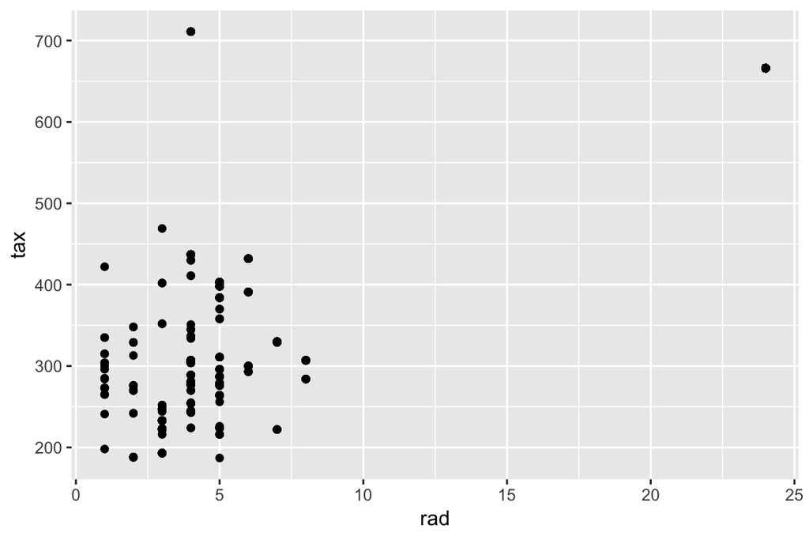

```r
ggplot(data = Boston, aes(x = rad, y = tax)) +
  geom_point()
```

I think we just found the reason for such a strong correlation. The outlier in the right upper corner might be the reason for it. We can test what happens if we remove it.

```r
library(dplyr)
cor_test <- as.data.frame(cbind(Boston$rad, Boston$tax))
cor_test <- filter(cor_test, V1 < 20)
cor(cor_test)
```

```
##           V1        V2
## V1 1.0000000 0.1882562
## V2 0.1882562 1.0000000
```

Removing this outlier the correlation becomes about 0.2. So my hypothesis about why their correlation is so strong was right.

## Standardising the dataset

To go on we need to standardise or to scale our dataset. It can be made easily with the function “scale”.

```r
b_scaled <- scale(Boston)
summary(b_scaled)
```

```
##       crim                 zn               indus
##  Min.   :-0.419367   Min.   :-0.48724   Min.   :-1.5563
##  1st Qu.:-0.410563   1st Qu.:-0.48724   1st Qu.:-0.8668
##  Median :-0.390280   Median :-0.48724   Median :-0.2109
##  Mean   : 0.000000   Mean   : 0.00000   Mean   : 0.0000
##  3rd Qu.: 0.007389   3rd Qu.: 0.04872   3rd Qu.: 1.0150
##  Max.   : 9.924110   Max.   : 3.80047   Max.   : 2.4202
##       chas              nox                rm               age
##  Min.   :-0.2723   Min.   :-1.4644   Min.   :-3.8764   Min.   :-2.3331
##  1st Qu.:-0.2723   1st Qu.:-0.9121   1st Qu.:-0.5681   1st Qu.:-0.8366
##  Median :-0.2723   Median :-0.1441   Median :-0.1084   Median : 0.3171
##  Mean   : 0.0000   Mean   : 0.0000   Mean   : 0.0000   Mean   : 0.0000
##  3rd Qu.:-0.2723   3rd Qu.: 0.5981   3rd Qu.: 0.4823   3rd Qu.: 0.9059
##  Max.   : 3.6648   Max.   : 2.7296   Max.   : 3.5515   Max.   : 1.1164
##       dis               rad               tax             ptratio
##  Min.   :-1.2658   Min.   :-0.9819   Min.   :-1.3127   Min.   :-2.7047
##  1st Qu.:-0.8049   1st Qu.:-0.6373   1st Qu.:-0.7668   1st Qu.:-0.4876
##  Median :-0.2790   Median :-0.5225   Median :-0.4642   Median : 0.2746
##  Mean   : 0.0000   Mean   : 0.0000   Mean   : 0.0000   Mean   : 0.0000
##  3rd Qu.: 0.6617   3rd Qu.: 1.6596   3rd Qu.: 1.5294   3rd Qu.: 0.8058
##  Max.   : 3.9566   Max.   : 1.6596   Max.   : 1.7964   Max.   : 1.6372
##      black             lstat              medv
##  Min.   :-3.9033   Min.   :-1.5296   Min.   :-1.9063
##  1st Qu.: 0.2049   1st Qu.:-0.7986   1st Qu.:-0.5989
##  Median : 0.3808   Median :-0.1811   Median :-0.1449
##  Mean   : 0.0000   Mean   : 0.0000   Mean   : 0.0000
##  3rd Qu.: 0.4332   3rd Qu.: 0.6024   3rd Qu.: 0.2683
##  Max.   : 0.4406   Max.   : 3.5453   Max.   : 2.9865
```

```r
b_scaled <- as.data.frame(b_scaled)
```

## New variable CRIME

Now we create a categorical variable of the crime rate. We are going to use the quantiles as the break points in this variable.

```r
library(dplyr)
breaks <- quantile(b_scaled$crim)
crime <- cut(b_scaled$crim, breaks = breaks, include.lowest = TRUE, labels = c('low', 'med_low', 'med_high', 'high'))
b_scaled <- b_scaled[,2:14]
b_scaled <- data.frame(b_scaled, crime)
```

## Dividing the dataset to train and test sets

For our future analysis we need to divide our data to train and test sets. We are going to do it now. We are going to put 80 per cents of the data into the train set.

```r
ind <- sample(nrow(b_scaled), size = nrow(b_scaled)*0.8)
train <- b_scaled[ind,]
test <- b_scaled[-ind,]
correct_classes <- test$crime
test <- test[,1:13]
```

## Fitting the LDA

We are going to fit the linear discriminant analysis on the train set. We are using the categorical crime rate as the target variable and all the other variables in the dataset as predictor variables.

```r
b_lda <- lda(crime ~ ., data = train)
```

The LDA plot are below.

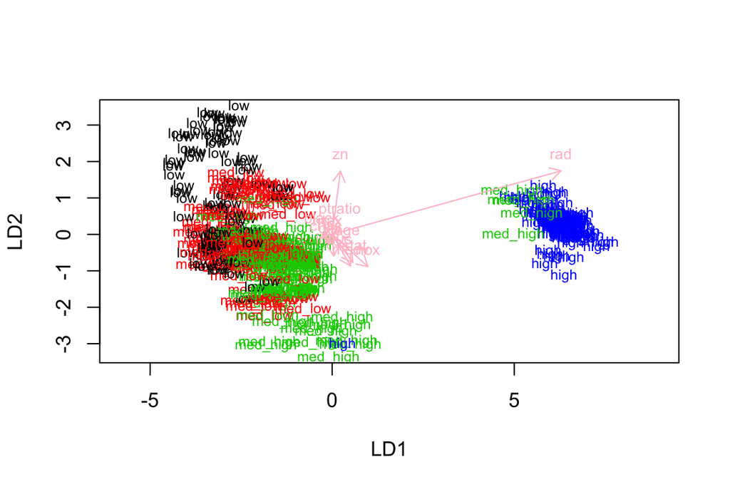

```r
b_arrows <- function(x, myscale = 1, arrow.heads = 0.1, color = 'pink', tex = 0.75, choices = c(1,2)) {
  heads = coef(x)
  arrows(x0 = 0, y0 = 0,
         x1 = myscale*heads[,choices[1]],
         y1 = myscale*heads[,choices[2]],
         col = color, length = arrow.heads)
  text(myscale*heads[,choices], labels = row.names(heads), cex = tex, col = color, pos = 3)
}
classes = as.numeric(train$crime)
plot(b_lda, dimen = 2, col = classes)
b_arrows(b_lda, myscale = 2)
```

## Predicting the classes

Then we are going to predict the classes with the LDA model on the test data.

```r
b_predict <- predict(b_lda, newdata = test)
t <- table(correct = correct_classes, predicted = b_predict$class)
t
```

```
##           predicted
## correct    low med_low med_high high
##   low       13       6        1    0
##   med_low    8      17        3    0
##   med_high   0       8       22    1
##   high       0       0        0   23
```

I think the model predicted the best class “high”. Maybe it is because this class defers a lot from other classes. To in which class we have the most errors we can create the same table but with the percentages.

```r
library(tidyverse)
c1 <- t[,1]/colSums(t)[1]
c2 <- t[,2]/colSums(t)[2]
c3 <- t[,3]/colSums(t)[3]
c4 <- t[,4]/colSums(t)[4]
t2 <- cbind(c1, c2, c3, c4)
colnames(t2) <- c('low', 'med_low', 'med_high', 'high')
t2
```

```
##                low   med_low   med_high       high
## low      0.6190476 0.1935484 0.03846154 0.00000000
## med_low  0.3809524 0.5483871 0.11538462 0.00000000
## med_high 0.0000000 0.2580645 0.84615385 0.04166667
## high     0.0000000 0.0000000 0.00000000 0.95833333
```

The prediction of the class “med_low” caused the biggest number of wrong predictions. And predictions of the class “high” were the most correct.

## K-means clustering

Now we are going to do k-means clustering on the data “Boston”. First of all, we have to decide how many clusters should we have. We can do by looking at how total WCSS changes when the number of clusters grows.

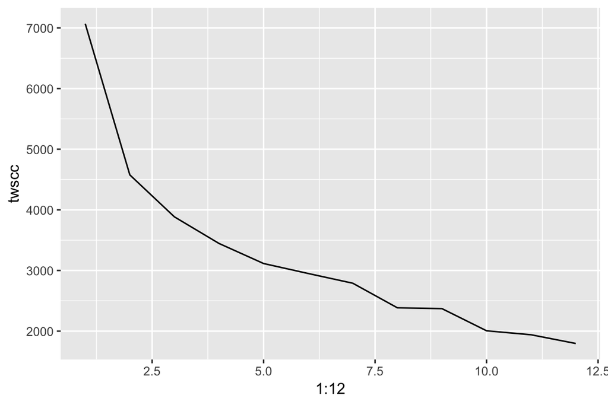

```r
data(Boston)
b_scaled <- scale(Boston)
dist <- dist(b_scaled)

set.seed(123)
k_max <- 12
twscc <- sapply(1:k_max, function(k){
  kmeans(b_scaled, k)$tot.withinss
})
qplot(x = 1:12, y = twscc, geom = 'line')
```

I think 2 is the optimal number of clusters.

Let’s do the k-means clustering with 2 clusters and interpret the results.

[figure not shown]

Based on these thoughts, class 2 includes not very attractive houses (bad air, located next to factories). The houses of class 1 are located better, the air is better and that’s why their price is usually higher.